# Simulation for ACF Lag-1 Values

# Overview, Goals

The process should be something like:

1. Simulate data from model
2. Fit model
3. Compute residuals
4. Compute residual ACF (*note: if you run `acf_out <- acf(resid(model), plot = FALSE)`, then `acf_out$acf[acf_out$lag == 1]` should be the value you want…*)
5. Store ACF value at lag 1

Repeat many times (1,000 is a good start) to get many exemplars of lag-1 ACF values.

May want to also repeat the entire process for cases with:

- Top priority:
  - Different numbers of cases per random effect group (more than just 2)
  - Vary random effect standard deviation (try 0.1, 0.25, 1, 2, 4?)
- Second priority:
  - Store slope estimates, SE, and p-value for fitted model in each loop iteration (will need to grab these from fitted model object or its summary; might help to use `broom` package and its function `tidy()`: https://broom.tidymodels.org/)
  - Also fit model without the RE and store ACF lag 1, slopes, SEs, and p-values
- Other ideas to discuss/try:
  - Random values of slope, intercept, RE variance parameters (sampled from distributions instead of fixed numbers)
  - Larger or smaller random effect variance
  - Binary or count model rather than just normal model

## Note!

It’s possible the lag-1 phenomenon only happens with nested random effects. If that is the case then the simulation will be more complicated, so pause…

# Tips about Process

You could use a [for loop](https://r4ds.hadley.nz/base-R.html#for-loops) and just do “by hand” all the steps of the process 1,000 (or however many times).

You might consider [writing a function](https://r4ds.hadley.nz/functions.html) (like maybe call it `get_acf1()`?) that takes as input all the “settings” (parameter values, model formula, etc) and then… generates a dataset, fits a model, gets the residuals, and grabs the ACF at lag 1. Then in your for loop, you would just call that function many times.

If you end up iterating over lots of different combinations of “settings” you might consider using either [apply functions](https://r4ds.hadley.nz/base-R.html#apply-family) or the tidyverse equivalent (which I admit I sometimes struggle with depending on the complexity of what I am trying to do!), the [map functions](https://purrr.tidyverse.org/index.html). There is a little bit of help online about how these two approaches match up with each other: https://purrr.tidyverse.org/articles/base.html

# Data Simulation

To get you started, here is code to simulate one dataset, assuming the model:

$$\text{response}_i = \alpha_{k_i} + 0 + 1.5 * x_{1i} - 0.5 * x_{2i} + \epsilon_i,$$

$$\epsilon \sim N(0, 1)$$

and $\alpha_{k_i}$ is the group-specific random intercept for the $k$th random-effect group. The $i$th datapoint will be a member of *one* of the $k$ random effect groups, and $\alpha_k \sim N(0,0.5)$

The predictors $x_1$ and $x_2$ will be simulated from standard normal (N(0,1)) distributions.

## Set parameter values and dataset size

```r
# rows in sim dataset
n <- 500
# size of RE groups
n_re <- 2
# x1 slope
b1 <- 1.5
# x2 slope
b2 <- -0.5
# random intercept standard deviation
group_sd <- 0.5
# residual standard deviation
resid_sd <- 1
```

```r
sim_data <- data.frame(
  # values of predictor #1
  x1 = rnorm(n, mean = 0, sd = 1),
  # values of predictor #2
  x2 = rnorm(n, mean = 0, sd = 1),
  # third candidate predictor that is NOT assoc w/respone
  x3 = rnorm(n, mean = 0, sd = 1),
  # random effect group assignment
  re_group = gl(n = floor(n/2),
                k = n_re,
                length = n),
  # residuals
  resid = rnorm(n, mean = 0, sd = resid_sd)) |>
  # random intercepts
  group_by(re_group) |>
  mutate(alpha = rnorm(1, mean = 0, sd = group_sd)) |>
  ungroup() |>
  mutate(response = 0 + alpha + b1 * x1 + b2 * x2 + resid)
```

Check out the result: each data point has its own predictor variable values and residual value. Each *random effect group* has the same random intercept value $\alpha$ (a sample from a normal distribution with mean 0 and sd = “what we specified”, which was 0.5 here).

```r
glimpse(sim_data)
```

```
Rows: 500
Columns: 7
$ x1       <dbl> 0.35334959, -0.47928599, -0.54257561, 0.33858706, 0.84528018,…
$ x2       <dbl> -0.25647274, -0.66959346, -0.05858328, 0.72333070, 0.70773039…
$ x3       <dbl> 0.47474969, -1.09753937, 0.70862735, 0.07212816, -0.15694438,…
$ re_group <fct> 1, 1, 2, 2, 3, 3, 4, 4, 5, 5, 6, 6, 7, 7, 8, 8, 9, 9, 10, 10,…
$ resid    <dbl> 0.56845129, 2.23851003, -0.10082992, 0.73870329, 0.56502264, …
$ alpha    <dbl> 0.49212262, 0.49212262, -0.48754917, -0.48754917, -0.47679034…
$ response <dbl> 1.71883466, 2.34650040, -1.37295087, 0.39736936, 1.00228738, …
```

We should be able to verify that the slope for `x1` is about `b1`, etc. via graphs for fitting the model…just to check:

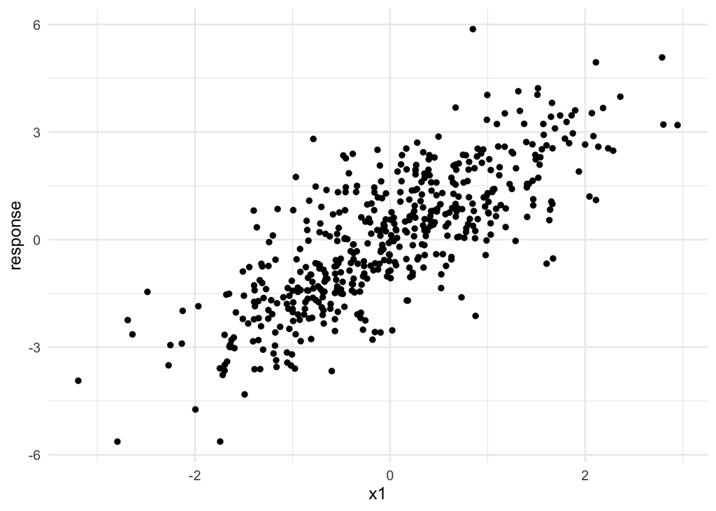

```r
gf_point(response ~ x1, data = sim_data)
```

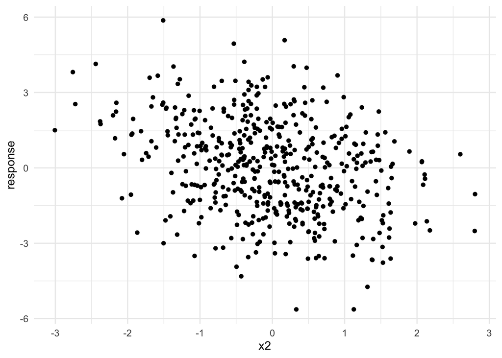

```r
gf_point(response ~ x2, data = sim_data)
```

```r
model <- glmmTMB(response ~ x1 + x2 + x3 + (1 | re_group),
                 data = sim_data)
summary(model)
```

```
 Family: gaussian  ( identity )
Formula:          response ~ x1 + x2 + x3 + (1 | re_group)
Data: sim_data

      AIC       BIC    logLik -2*log(L)  df.resid
   1477.6    1502.9    -732.8    1465.6       494

Random effects:

Conditional model:
 Groups   Name        Variance Std.Dev.
 re_group (Intercept) 0.1998   0.4470
 Residual             0.9161   0.9571
Number of obs: 500, groups:  re_group, 250

Dispersion estimate for gaussian family (sigma^2): 0.916

Conditional model:
            Estimate Std. Error z value Pr(>|z|)
(Intercept)  0.04087    0.05133   0.796    0.426
x1           1.42817    0.04565  31.286   <2e-16 ***
x2          -0.52227    0.04878 -10.707   <2e-16 ***
x3          -0.06029    0.04701  -1.282    0.200
---
Signif. codes:  0 '***' 0.001 '**' 0.01 '*' 0.05 '.' 0.1 ' ' 1
```

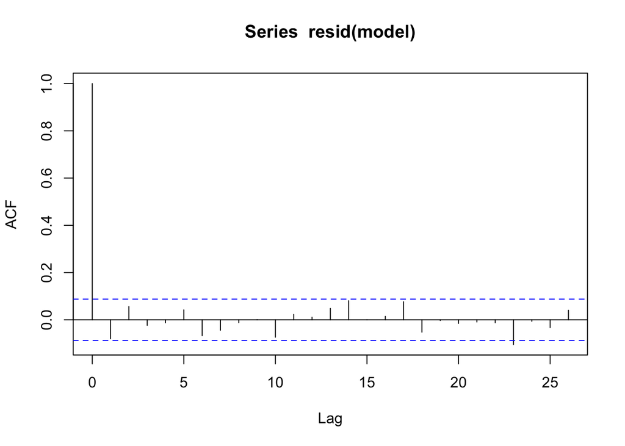

```r
acf(resid(model))
```